# Keith Wampler

## PGRS 560: Introduction to Machine Learning

## Fall 2025

# Homework 4: ACS Income Prediction

This homework assignment guides you through building and evaluating machine learning models to predict individual income using the American Community Survey (ACS) microdata. You will implement both an XGBoost model and a fully connected neural network using Keras, following the workflows demonstrated in the provided tutorials. The focus will be on log-transforming the income target, feature engineering, model training, and evaluation.

## Setup

### Data

Use the ACS microdata file `usa_00005.dta` that I shared on Populi. This dataset contains individual-level records with demographic and socioeconomic features, including total personal income (`inctot`).

## Task 1: Load and Log-transform ACS Data

Following the final attempt in the XGBoost tutorial, sample 10% of the microdata, drop any rows where `inctot == 9999999`.

```python
import pandas as pd
import numpy as np
import xgboost as xgb
from sklearn.model_selection import train_test_split
import matplotlib.pyplot as plt

# Load data
data = pd.read_stata("/Users/keith/Documents/code/Intro to ML 2025/data/raw/usa_00005.dta")

# Sample 10%
data = data.sample(frac=0.1, random_state=42).reset_index(drop=True)

# Drop rows with missing income (9999999)
data = data[data['inctot'] != 9999999]
print(f"Data shape after dropping missing income: {data.shape}")
```

```
Data shape after dropping missing income: (289210, 144)
```

**Question 1:** Why is it not necessary to impute or filter our missing values for other features?

**Answer 1:**

XGBoost handles missing values natively. When a value is missing, the tree learns a default direction for that specific split that minimizes the loss function. Therefore, explicit imputation is often unnecessary unless we have specific domain knowledge about why the data is missing

### Task 1.1: Log-transform Income

Instead of predicting income directly, we will predict log-income. Create a new target column `log_inctot` by applying the natural log transformation to `inctot` after adding 1 (i.e., `np.log1p`). Filter out any rows where `inctot` is less than or equal to zero before applying the log transformation. Make a histogram of both the original income and log-income distributions to visualize the effect of the transformation.

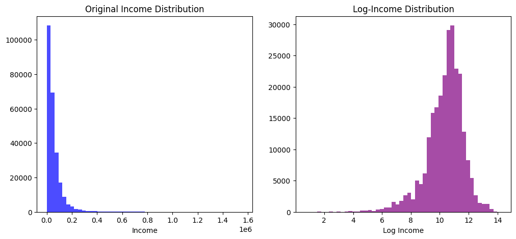

```python
# Filter out non-positive income values
data = data[data['inctot'] > 0]

# Log-transform income
data['log_inctot'] = np.log1p(data['inctot'])

# Visualize original and log-transformed income distributions
plt.figure(figsize=(12, 5))

plt.subplot(1, 2, 1)
plt.hist(data['inctot'], bins=50, color='blue', alpha=0.7)
plt.title('Original Income Distribution')
plt.xlabel('Income')

plt.subplot(1, 2, 2)
plt.hist(data['log_inctot'], bins=50, color='purple', alpha=0.7)
plt.title('Log-Income Distribution')
plt.xlabel('Log Income')

plt.show()
```

**Question 2:** What are the advantages of predicting log-income rather than income directly?

**Answer 2:**

Income data can be lopsided due to the disparity because the majority of the population and billionares. These extreme high-earners can confuse the model, causing it to focus too much on them rather than the average person. Using a log transformation smooths out these extremes, making the data easier for the model to understand and predict accurately.

## Task 2: Feature Engineering and Encoding

Split the data into a feature matrix `X` and target vector `y` (the log-income column created above). Perform one-hot encoding on all categorical features, dropping sparse columns whose proportion of non-zero entries falls below 1%. The feature matrix `X` should include all columns except `inctot` and `log_inctot`. The target vector `y` should be the `log_inctot` column. Mimic the one-hot encoding workflow from the tutorial: build dummies for every categorical column in `X`, then drop sparse columns whose proportion of non-zero entries falls below 1%.

```python
# Split features and target
y = data['log_inctot']
X = data.drop(columns=['inctot', 'log_inctot'])

# Hot-encode
X_encoded = pd.get_dummies(X, drop_first=False)

# Drop sparse columns (< 1% non-zero entries)
cols_to_keep = [col for col in X_encoded.columns if (X_encoded[col] != 0).mean() > 0.01]
X_encoded = X_encoded[cols_to_keep]

print(f"Shape after encoding and pruning: {X_encoded.shape}")
```

```
Shape after encoding and pruning: (253800, 695)
```

### Task 2.1: Train/Test Split

Split the encoded data into training and testing sets (80/20).

```python
X_train, X_test, y_train, y_test = train_test_split(
    X_encoded, y, test_size=0.2, random_state=42
)
```

## Task 3: XGBoost Modeling (Log Target)

Reproduce the final modeling attempt from `examples/XGBoost.ipynb`, but treat the log-income target as the label. Work through the following subtasks and insert your own code in each block.

### Task 3.1: Build DMatrix Objects

Create `xgb.DMatrix` objects for both the training and test splits using the log-income labels.

```python
dtrain = xgb.DMatrix(X_train, label=y_train)
dtest = xgb.DMatrix(X_test, label=y_test)
```

### Task 3.2: Hyperparameter Dictionary

Start from the tutorial’s baseline settings (e.g., `eta = 1`, `max_depth = 10`, `min_child_weight = 100`, RMSE metric, early stopping after 50 rounds) and justify any deviations you make. Use the `reg:squarederror` objective and `rmse` evaluation metric.

```python
# Baseline parameters
params = {
    'eta': 1,
    'max_depth': 10,
    'min_child_weight': 100,
    'objective': 'reg:squarederror',
    'eval_metric': 'rmse',
    'verbosity': 0
}
```

### Task 3.3: Hyperparameter Tuning

Perform a grid search over the `eta = [1, 0.1, 0.01]` and `max_depth = [3, 6, 10]` parameters to identify the best combination based on validation RMSE (i.e., for each combination of `eta` and `max_depth`, train a model and record the validation RMSE). Use early stopping with a patience of 50 rounds and a maximum of 10,000 training rounds.

```python
eta_vals = [1, 0.1, 0.01]
max_depth_vals = [3, 6, 10]
best_rmse = float("inf")
best_params = {}

results = []

for eta in eta_vals:
    for depth in max_depth_vals:
        # Update parameters
        current_params = params.copy()
        current_params['eta'] = eta
        current_params['max_depth'] = depth

        # Train model with early stopping
        evallist = [(dtrain, 'train'), (dtest, 'eval')]

        model = xgb.train(
            current_params,
            dtrain,
            num_boost_round=10000,
            evals=evallist,
            early_stopping_rounds=50,
            verbose_eval=False
        )

        # best_score gives the best rmse found during training
        val_rmse = model.best_score
        results.append((eta, depth, val_rmse))
        print(f"Eta: {eta}, Depth: {depth}, RMSE: {val_rmse}")

        if val_rmse < best_rmse:
            best_rmse = val_rmse
            best_params = current_params
            best_model = model

print(f"\nBest Params: eta={best_params['eta']}, depth={best_params['max_depth']}")
print(f"Best Validation RMSE: {best_rmse}")
```

```
Eta: 1, Depth: 3, RMSE: 0.8287956838307373
Eta: 1, Depth: 6, RMSE: 0.8496526069055117
Eta: 1, Depth: 10, RMSE: 0.8550343552675418
Eta: 0.1, Depth: 3, RMSE: 0.8050965173165748
Eta: 0.1, Depth: 6, RMSE: 0.8037526257457619
Eta: 0.1, Depth: 10, RMSE: 0.8034585616028259
Eta: 0.01, Depth: 3, RMSE: 0.8123306601720324
Eta: 0.01, Depth: 6, RMSE: 0.8030736641127065
Eta: 0.01, Depth: 10, RMSE: 0.7998647541761034

Best Params: eta=0.01, depth=10
Best Validation RMSE: 0.7998647541761034
```

**Question 3:** Which hyperparameter combination yielded the lowest validation RMSE, and what was that RMSE value? Based on the results, do you think you need to expand the grid search other values or parameters? (Note: You do not need to actually search for more parameters, just discuss.)

**Answer 3:**

The hyperparameter combination that yielded the lowest validation RMSE was eta = 0.01 with a max_depth of 10. The RMSE value was ~0.79987.

Given that the lowest RMSE was at the edge of our grid, it may be beneficial to explore smaller `eta` values (e.g. 0.001) and larger `max_depth` values (e.g. 12) to see if further improvements can be achieved. Likely, the RMSE will not improve significantly, but it is worth investigating if computational resources are an issue.

### Task 3.4: Final Model Training

Using the best hyperparameters from Task 3.3, train a final XGBoost model on the full dataset.

```python
# Update parameters with best values
best_params = params.copy()
best_params['eta'] = 0.01
best_params['max_depth'] = 10

# Train the final model
final_xgb = xgb.train(
    best_params,
    dtrain,
    num_boost_round=10000,
    evals=[(dtrain, 'train'), (dtest, 'eval')],
    early_stopping_rounds=50,
    verbose_eval=100
)
```

### Task 3.5: Evaluate Predictions

Plot predicted vs. actual log-income values on the test set using a scatter plot.

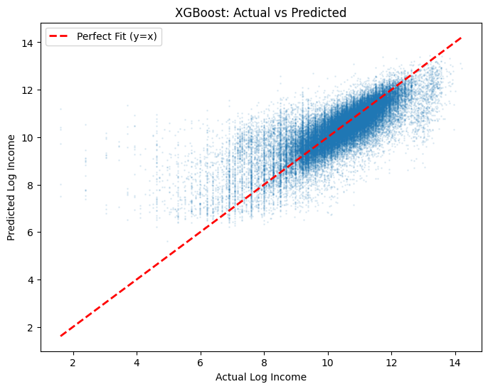

```python
# Generate predictions
y_pred_xgb = final_xgb.predict(dtest, iteration_range=(0, final_xgb.best_iteration + 1))

# Plot
plt.figure(figsize=(8, 6))
plt.scatter(y_test, y_pred_xgb, alpha=0.1, s=1)
plt.plot([y_test.min(), y_test.max()], [y_test.min(), y_test.max()], 'r--', lw=2, label='Perfect Fit (y=x)')
plt.xlabel("Actual Log Income")
plt.ylabel("Predicted Log Income")
plt.title("XGBoost: Actual vs Predicted")
plt.legend()
plt.show()
```

**Question 4:** Qualitatively, how well do the predictions align with the actual values?

**Answer 4:**

The predictions align well with actual values, as most points cluster tightly along the red diagonal line, particularly in the middle-to-high income ranges. However, the model struggles with lower incomes (log income < 8), where it systematically over-predicts values. One interesting feature at the the vertical lines visible in the plot. My guess is that these are artifacts caused by survey respondents rounding their income figures.

## Task 4: Neural Network Modeling (Keras)

Use the structure from `examples/neural_nets_simple.ipynb` to fit a fully connected neural network on the same encoded features and log-income target. Use the same train/test split as in Task 2.1.

### Task 4.1: Prepare Data for Keras

If necessary, convert the training and test feature matrices and target vectors into NumPy arrays suitable for Keras. **Note:** You may have already done this in Task 2.1.

```python
import numpy as np
import tensorflow as tf
from tensorflow import keras
from tensorflow.keras import layers
from sklearn.preprocessing import StandardScaler

#set random seeds for reproducibility
np.random.seed(666)
tf.random.set_seed(666)


x_train_raw = np.array(X_train).astype('float32')
x_test_raw = np.array(X_test).astype('float32')
y_train_raw = np.array(y_train).astype('float32')
y_test_raw = np.array(y_test).astype('float32')

# Scale the Inputs
scaler = StandardScaler()
x_train = scaler.fit_transform(x_train_raw)
x_test = scaler.transform(x_test_raw)

# Clip to valid Log-Income range (0 to 16) to remove Infinities
y_train = np.clip(y_train_raw, 0, 16)
y_test = np.clip(y_test_raw, 0, 16)

#check data
x_train = np.nan_to_num(x_train, nan=0.0)
x_test = np.nan_to_num(x_test, nan=0.0)
y_train = np.nan_to_num(y_train, nan=0.0)
y_test = np.nan_to_num(y_test, nan=0.0)

print("Data successfully reset, scaled, and clipped.")
print(f"Input Min/Max: {x_train.min():.2f} / {x_train.max():.2f}")
print(f"Target Min/Max: {y_train.min():.2f} / {y_train.max():.2f}")
```

```
Data successfully reset, scaled, and clipped.
Input Min/Max: -12.60 / 18.47
Target Min/Max: 0.69 / 14.26
```

### Task 4.2: Define the Architecture

Implement a dense network with several ReLU-activated hidden layers (e.g., 256-128-64) and compile it with the Adam optimizer and MSE loss.

**Question 5:** What should the input dimension be for the first layer of the network be?

**Answer 5:**

The input dimension for the first layer of the network should be equal to the number of features in the encoded feature matrix `X`. This is because each input sample to the network must have a value for each dimension.

```python
model = keras.Sequential([
    layers.Dense(256, activation="relu", input_shape=(x_train.shape[1],)),
    layers.Dense(128, activation="relu"),
    layers.Dense(64, activation="relu"),
    layers.Dense(1)
])

# We can use a standard learning rate now that data is clean
model.compile(optimizer='adam', loss='mse')

history = model.fit(x_train, y_train,
                    validation_data=(x_test, y_test),
                    epochs=200,
                    batch_size=1024,
                    verbose=1,
                    callbacks=[
                        keras.callbacks.EarlyStopping(monitor="val_loss", patience=10, restore_best_weights=True)
                    ])
```

```
199/199 ━━━━━━━━━━━━━━━━━━━━ 2s 8ms/step - loss: 3.5263 - val_loss: 0.9254
199/199 ━━━━━━━━━━━━━━━━━━━━ 1s 7ms/step - loss: 0.8333 - val_loss: 0.8496
199/199 ━━━━━━━━━━━━━━━━━━━━ 1s 6ms/step - loss: 0.7364 - val_loss: 0.8227
199/199 ━━━━━━━━━━━━━━━━━━━━ 1s 6ms/step - loss: 0.6799 - val_loss: 0.8116
199/199 ━━━━━━━━━━━━━━━━━━━━ 1s 6ms/step - loss: 0.6405 - val_loss: 0.8067
199/199 ━━━━━━━━━━━━━━━━━━━━ 1s 6ms/step - loss: 0.6098 - val_loss: 0.8060
199/199 ━━━━━━━━━━━━━━━━━━━━ 1s 6ms/step - loss: 0.5849 - val_loss: 0.8106
199/199 ━━━━━━━━━━━━━━━━━━━━ 1s 6ms/step - loss: 0.5639 - val_loss: 0.8158
199/199 ━━━━━━━━━━━━━━━━━━━━ 1s 6ms/step - loss: 0.5450 - val_loss: 0.8218
199/199 ━━━━━━━━━━━━━━━━━━━━ 1s 6ms/step - loss: 0.5277 - val_loss: 0.8302
199/199 ━━━━━━━━━━━━━━━━━━━━ 1s 6ms/step - loss: 0.5118 - val_loss: 0.8367
199/199 ━━━━━━━━━━━━━━━━━━━━ 1s 7ms/step - loss: 0.4967 - val_loss: 0.8449
199/199 ━━━━━━━━━━━━━━━━━━━━ 1s 6ms/step - loss: 0.4827 - val_loss: 0.8544
199/199 ━━━━━━━━━━━━━━━━━━━━ 1s 7ms/step - loss: 0.4688 - val_loss: 0.8634
199/199 ━━━━━━━━━━━━━━━━━━━━ 1s 7ms/step - loss: 0.4541 - val_loss: 0.8734
199/199 ━━━━━━━━━━━━━━━━━━━━ 1s 6ms/step - loss: 0.4412 - val_loss: 0.8856
```

### Task 4.3: Initial Training

Fit the model on the training data while validating on the test set. Run the training for a maximum of 1,000 epochs. I have some example code below that includes early stopping to prevent overfitting. You may adjust as needed. The `patience` parameter in the `EarlyStopping` callback controls how many epochs with no improvement on the validation loss to wait before stopping training. The `batch_size` is a parameter that we haven't discussed in class, but it limits the amount of data the model is exposed to at once during training. You can leave it at 1024 for this assignment.

```python
history = model.fit(
    x_train,
    y_train,
    validation_data=(x_test, y_test),
    epochs=1000,
    batch_size=1024,
    verbose=1,
    callbacks=[
        keras.callbacks.EarlyStopping(
            monitor="val_loss",
            patience=10,
            restore_best_weights=True,
        )
    ],
)
```

```
199/199 ━━━━━━━━━━━━━━━━━━━━ 1s 7ms/step - loss: 0.6229 - val_loss: 0.8328
199/199 ━━━━━━━━━━━━━━━━━━━━ 1s 6ms/step - loss: 0.5883 - val_loss: 0.8315
199/199 ━━━━━━━━━━━━━━━━━━━━ 1s 7ms/step - loss: 0.5646 - val_loss: 0.8304
199/199 ━━━━━━━━━━━━━━━━━━━━ 1s 6ms/step - loss: 0.5573 - val_loss: 0.8393
199/199 ━━━━━━━━━━━━━━━━━━━━ 1s 6ms/step - loss: 0.5298 - val_loss: 0.8613
199/199 ━━━━━━━━━━━━━━━━━━━━ 1s 7ms/step - loss: 0.5007 - val_loss: 0.8589
199/199 ━━━━━━━━━━━━━━━━━━━━ 1s 6ms/step - loss: 0.4777 - val_loss: 0.8747
199/199 ━━━━━━━━━━━━━━━━━━━━ 1s 6ms/step - loss: 0.4570 - val_loss: 0.8946
199/199 ━━━━━━━━━━━━━━━━━━━━ 1s 6ms/step - loss: 0.4381 - val_loss: 0.9024
199/199 ━━━━━━━━━━━━━━━━━━━━ 1s 6ms/step - loss: 0.4210 - val_loss: 0.9156
199/199 ━━━━━━━━━━━━━━━━━━━━ 1s 6ms/step - loss: 0.4050 - val_loss: 0.9370
199/199 ━━━━━━━━━━━━━━━━━━━━ 1s 6ms/step - loss: 0.3905 - val_loss: 0.9506
199/199 ━━━━━━━━━━━━━━━━━━━━ 1s 6ms/step - loss: 0.3769 - val_loss: 0.9635
```

#### Task 4.3a

Plot the training and validation loss curves over epochs.

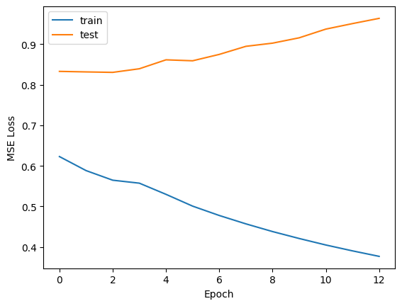

```python
# plot the loss curves
plt.plot(history.history["loss"], label="train")
plt.plot(history.history["val_loss"], label="test")
plt.xlabel("Epoch")
plt.ylabel("MSE Loss")
plt.legend()
plt.show()
```

**Question 6:** Based on the loss curves, does the model appear to be underfitting, overfitting, or well-fitted? Justify your answer.

**Answer 6:**

These data indicate that the model is overfitting the data. The training loss continues to decrease steadily, indicating that the model is learning the training data well. However, the validation loss starts to increase after a certain number of epochs, suggesting that the model is starting to memorize the training data rather than generalizing to unseen data.